# Practical Machine Learning final project

Mikael Lindstrom

July 16, 2016

# Introduction

Using devices such as Jawbone Up, Nike FuelBand, and Fitbit it is now possible to collect a large amount of data about personal activity relatively inexpensively. These type of devices are part of the quantified self movement - a group of enthusiasts who take measurements about themselves regularly to improve their health, to find patterns in their behavior, or because they are tech geeks. One thing that people regularly do is quantify how much of a particular activity they do, but they rarely quantify how well they do it. The data is generated from accelerometers on the belt, forearm, arm, and dumbell of 6 participants. They were asked to perform barbell lifts correctly and incorrectly in 5 different ways. The data comes from http://groupware.les.inf.puc-rio.br/har.

The goal is to use the ata to predict the manner in which they did the exercise.

# Loading

Libraries used for this project are first loaded into R.

```r
library(caret)
library(rpart)
library(rpart.plot)
library(RColorBrewer)
library(rattle)
library(randomForest)
set.seed(11111)
```

The training data and test data are loaded from the website.

```r
if (!file.exists("pml-training.csv")) {
    download.file("http://d396qusza40orc.cloudfront.net/predmachlearn/pml-training.csv",
    destfile = "pml-training.csv")
}
if (!file.exists("pml-testing.csv")) {
    download.file("http://d396qusza40orc.cloudfront.net/predmachlearn/pml-testing.csv",
    destfile = "pml-testing.csv")
}

trainingSet <- read.csv("pml-training.csv",
                        na.strings=c("NA","#DIV/0!",""))
testingSet <- read.csv("pml-testing.csv",
                       na.strings=c("NA","#DIV/0!",""))
```

# Cleaning

The data is cleaned before it can be used:

- Remove any variables containing all NAs
- Remove any near zero variance columns
- Remove the first 6 rows as they contain the id, participant timestamp etc.

```r
NACols<-colnames(testingSet)[colSums(is.na(testingSet)) > 0]
trainingSet<-trainingSet[,!(names(trainingSet) %in% NACols)]

nzv <- nearZeroVar(trainingSet, saveMetrics=TRUE)
trainingSet<-trainingSet[,nzv$nzv==FALSE]
trainingSet<-trainingSet[,-(1:6)]
```

## Bootstrap

```r
inTrain <- createDataPartition(y=trainingSet$classe, p=0.7, list=FALSE)
myTraining <- trainingSet[inTrain,]
myTesting <- trainingSet[-inTrain,]
dim(myTraining)
```

```
## [1] 13737    53
```

```r
dim(myTesting)
```

```
## [1] 5885   53
```

# Random Forest

First trying random forest. Starting with out-of-the-box parameters.

```r
modFitRF <- randomForest(classe ~ ., data=myTraining)
print(modFitRF)
```

```
##
## Call:
##  randomForest(formula = classe ~ ., data = myTraining)
##                Type of random forest: classification
##                      Number of trees: 500
## No. of variables tried at each split: 7
##
##         OOB estimate of  error rate: 0.58%
## Confusion matrix:
##      A    B    C    D    E  class.error
## A 3903    2    0    0    1 0.0007680492
## B   18 2632    8    0    0 0.0097817908
## C    0   17 2376    3    0 0.0083472454
## D    0    0   22 2229    1 0.0102131439
## E    0    0    3    5 2517 0.0031683168
```

```r
predRF <- predict(modFitRF, myTesting, type = "class")
confMatrixRF<-confusionMatrix(predRF, myTesting$classe)
print(confMatrixRF)
```

```
## Confusion Matrix and Statistics
##
##           Reference
## Prediction    A    B    C    D    E
##          A 1674    3    0    0    0
##          B    0 1135    5    0    0
##          C    0    1 1021    9    1
##          D    0    0    0  954    2
##          E    0    0    0    1 1079
##
## Overall Statistics
##
##                Accuracy : 0.9963
##                  95% CI : (0.9943, 0.9977)
##     No Information Rate : 0.2845
##     P-Value [Acc > NIR] : < 2.2e-16
##
##                   Kappa : 0.9953
##  Mcnemar's Test P-Value : NA
##
## Statistics by Class:
##
##                      Class: A Class: B Class: C Class: D Class: E
## Sensitivity            1.0000   0.9965   0.9951   0.9896   0.9972
## Specificity            0.9993   0.9989   0.9977   0.9996   0.9998
## Pos Pred Value         0.9982   0.9956   0.9893   0.9979   0.9991
## Neg Pred Value         1.0000   0.9992   0.9990   0.9980   0.9994
## Prevalence             0.2845   0.1935   0.1743   0.1638   0.1839
## Detection Rate         0.2845   0.1929   0.1735   0.1621   0.1833
## Detection Prevalence   0.2850   0.1937   0.1754   0.1624   0.1835
## Balanced Accuracy      0.9996   0.9977   0.9964   0.9946   0.9985
```

With out of the box random forest prediction, an accuracy of 0.9962617 was achieved. I.e. very good (excellent even!).

# Decision Tree

Trying another model - Decision tree that is easier to visualize.

```r
modFitDT <- train(classe ~ ., data = myTraining, method="rpart")
print(modFitDT)
```

```
## CART
##
## 13737 samples
##    52 predictor
##     5 classes: 'A', 'B', 'C', 'D', 'E'
##
## No pre-processing
## Resampling: Bootstrapped (25 reps)
## Summary of sample sizes: 13737, 13737, 13737, 13737, 13737, 13737, ...
## Resampling results across tuning parameters:
##
##   cp          Accuracy   Kappa
##   0.03651714  0.5152853  0.37232051
##   0.06021768  0.4058931  0.19234231
##   0.11453565  0.3195021  0.05363252
##
## Accuracy was used to select the optimal model using  the largest value.
## The final value used for the model was cp = 0.03651714.
```

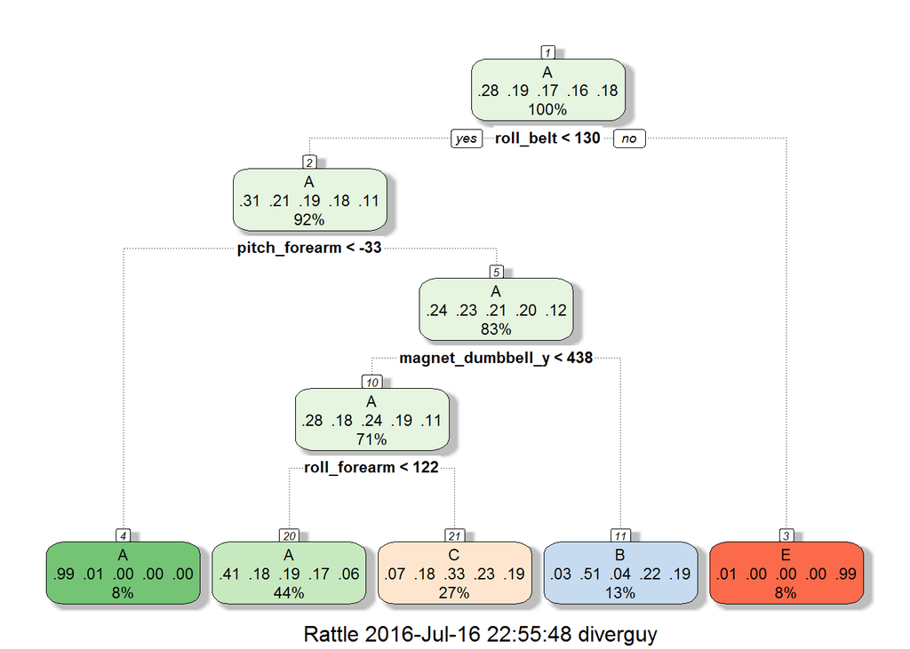

```r
fancyRpartPlot(modFitDT$finalModel)
```

```r
predDT <- predict(modFitDT, myTesting)
confMatrixDT<-confusionMatrix(predDT, myTesting$classe)
print(confMatrixDT)
```

```
## Confusion Matrix and Statistics
##
##           Reference
## Prediction    A    B    C    D    E
##          A 1502  480  464  410  164
##          B   29  388   30  183  144
##          C  141  271  532  371  281
##          D    0    0    0    0    0
##          E    2    0    0    0  493
##
## Overall Statistics
##
##                Accuracy : 0.4953
##                  95% CI : (0.4825, 0.5082)
##     No Information Rate : 0.2845
##     P-Value [Acc > NIR] : < 2.2e-16
##
##                   Kappa : 0.341
##  Mcnemar's Test P-Value : NA
##
## Statistics by Class:
##
##                      Class: A Class: B Class: C Class: D Class: E
## Sensitivity            0.8973  0.34065   0.5185   0.0000  0.45564
## Specificity            0.6395  0.91867   0.7810   1.0000  0.99958
## Pos Pred Value         0.4974  0.50129   0.3333      NaN  0.99596
## Neg Pred Value         0.9400  0.85306   0.8848   0.8362  0.89072
## Prevalence             0.2845  0.19354   0.1743   0.1638  0.18386
## Detection Rate         0.2552  0.06593   0.0904   0.0000  0.08377
## Detection Prevalence   0.5132  0.13152   0.2712   0.0000  0.08411
## Balanced Accuracy      0.7684  0.62966   0.6498   0.5000  0.72761
```

With out of the box Decision Tree model, an accuracy of 0.4953271 was achieved, i.e. a lot lower than the random forest model.

# Results

Using random forest model achieved an accuracy of 0.9962617 and an expected out of sample error of 0.0037383.

Predicting the results on the test data produced the following output:

```r
predicationsFinal<-predict(modFitRF, newdata=testingSet)
print(predicationsFinal)
```

```
##  1  2  3  4  5  6  7  8  9 10 11 12 13 14 15 16 17 18 19 20
##  B  A  B  A  A  E  D  B  A  A  B  C  B  A  E  E  A  B  B  B
## Levels: A B C D E
```